# Речной сток для природы и орошения

Шаг 4 из 8

Правило экологического стока в пяти блоках TaqSim с оценкой через fishy

Автор

Организация

Dr. Tobias Siegfried

[hydrosolutions GmbH](https://www.hydrosolutions.ch)

Опубликовано

8 октября 2026

**hydrosolutions GmbH** · Venusstrasse 29, 8050 Zürich, Switzerland · www.hydrosolutions.ch · hs@hydrosolutions.ch · +41 43 535 05 80

# 1 Вопрос

Река питает канал, а канал — поля Самарканда. Всё, что канал не забирает, остаётся в реке и течёт дальше. Оператор гидроузла решает не только, сколько воды оставить, но и как это сделать:

- **Оставлять долю.** Каждый день фиксированная доля суточного стока остаётся в реке, независимо от его величины.
- **Гарантировать минимум.** Каждый день первые заданные кубометры в секунду остаются в реке; канал забирает только превышение.

Оба правила могут дать культурам одинаковый годовой объём, но создают разный режим реки. Этот блокнот строит минимальную модель TaqSim, показывающую разницу на реальном Зарафшане у Раватходжи, и оценивает реку индексом изменения гидрологического режима.

**Что вы узнаете**

- Как работает правило экологического стока TaqSim (`EFlowSplit`) и как связать его с источником, каналом и конечным узлом.
- Как индекс изменения режима (IARI из fishy, основанный на 33 показателях IHA) превращает суточный ряд в число и чего это число не отражает.
- Почему при одинаковом водоснабжении культур гарантированный минимум сохраняет более близкий к естественному режим, чем доля: важна форма правила, а не только объём.

> **Термины.** Вода, оставленная в реке для природы, — экологический сток (e-flow). 33 показателя изменения гидрологического режима (IHA; Richter et al. 1996) описывают величины стока, сроки, экстремумы, импульсы и скорость изменений. IARI (ISPRA 2011) сравнивает показатели естественного и изменённого рядов и усредняет результат: 0 означает попадание каждого показателя в естественный диапазон. План, который никакой другой не превосходит по обеим целям, называется Парето-оптимальным; здесь — недоминируемым.

**Подписи рисунков и таблиц.** Inflow — приток; Headworks — гидроузел; Canal gate — водозабор; Fields — поля; River end — конец реки; record — наблюдения; flow − reserve — сток минус резерв; demand of the day — суточная потребность; not needed — избыток; reserve — резерв; share — доля; ceiling — предел. SOURCE — источник, REACH — участок, SINK — конечный узел. Ravatkhoja record — наблюдения Раватходжи; scored years — оцениваемые годы; canal demand — потребность канала; natural — естественный; river below the headworks — река ниже гидроузла; taken by the canal — отбор в канал; guaranteed minimum — гарантированный минимум. Indicator score — оценка показателя; crops supplied — обеспеченность культур; river score — оценка реки; endpoints — крайние планы; leave a share — оставить долю; guarantee a minimum — гарантировать минимум; share with a ceiling — доля с пределом. Английские идентификаторы столбцов сохранены для сопоставления с Python: year — год; mean/min/max_m3s — средний/минимальный/максимальный расход, м³/с; share_pct — доля, %; ceiling_m3s — предел, м³/с; crops_pct — обеспеченность культур, %; score — оценка; scored — число оценённых показателей; score_is_total — доступны все показатели; classification — класс; unbeaten — недоминируемый; lowest_flow_m3s — минимальный расход. Классы: elevato — близко к естественному; buono — хорошее; non_buono — изменённое. true/false — да/нет; null — значение отсутствует.

# 2 Система из пяти блоков

TaqSim представляет водную систему сетью блоков, соединённых рёбрами. Здесь пять блоков и пять рёбер: приток, два участка с правилами и два конечных узла.

```python
# Стандартные инструменты
import inspect  # для показа исходного кода функции в блокноте
import json
import logging
from pathlib import Path

import matplotlib.pyplot as plt
import numpy as np
import polars as pl  # таблицы; новые TaqSim и fishy работают с polars
from IPython.display import Markdown

# Эталонная модель игры (workshop/eflow_game/src/eflow_game/model.py): система TaqSim, оценки fishy,
# сетка планов и экспорт. Все результаты игры вычислены этими функциями.
from eflow_game import model as m
from eflow_game.model import Plan, build_system, demand_curve, load_inflow, run_year, score_river, twin_year

logging.basicConfig(level=logging.WARNING)
DAY = 86400.0

# Готовая сетка: каждый план рассчитан в TaqSim за 2019–2023 и оценён fishy
DATA = json.loads(m.DATA_FILE.read_text())
PLANS = pl.DataFrame(DATA["plans"]).select(
    "id", "name", "share_pct", "ceiling_m3s", "crops_pct", "score", "score_is_total", "scored", "classification", "unbeaten", "lowest_flow_m3s"
)
META = DATA["meta"]
Markdown(
    f"Загружено планов: {len(DATA['plans'])} ({META['runs']} годовых расчётов TaqSim по {META['mean_run_seconds']:.1f} с, "
    f"процессов: {META['workers']}, всего {META['wall_seconds_total'] / 60:.1f} мин; создано {META['built']})."
)
```

Загружен 91 план (455 годовых расчётов TaqSim по 12.3 с, 10 процессов, всего 9.4 мин; создано 2026-10-06T13:20:55).

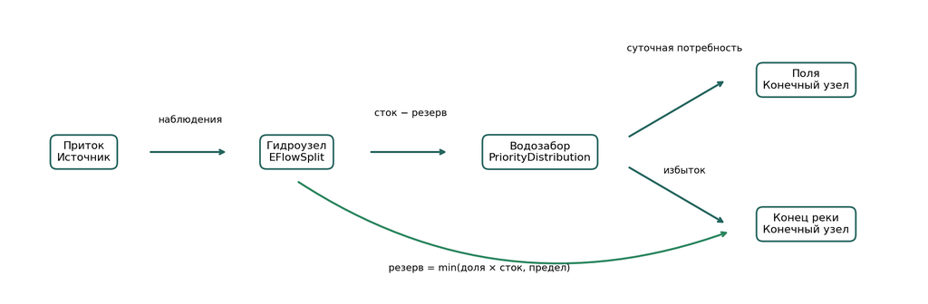

Рисунок 1: Модель в виде сети. Вода течёт слева направо. Правила задаются двум участкам; конечные узлы лишь записывают поступления.

| Блок | Тип | Правило | На реальной реке |
| --- | --- | --- | --- |
| Приток | Source | передаёт измеренный суточный сток | Зарафшан на гидропосту Раватходжа |
| Гидроузел | Reach с `EFlowSplit` | оставляет в реке min(доля × сток, предел), остальное передаёт дальше | Раватходжинский гидроузел |
| Водозабор канала | Reach с `PriorityDistribution` | подаёт полям суточную потребность, остальное возвращает в реку | головная часть Самаркандских каналов |
| Поля | Sink | записывает поступление воды культурам | Даргом, Мирзапай, Аккарадья |
| Конец реки | Sink | записывает поступление воды для природы | Зарафшан ниже Раватходжи |

Между блоками нет накопления и потерь, поэтому каждый день *приток = вода в конце реки + вода полям*. Модель работает с суточным шагом, один календарный год за запуск; пять лет 2019–2023 оцениваются совместно.

## 2.1 Река

```python
# Суточные наблюдения Раватходжи за 2010–2023 в модели: столбцы date и q (м³/с)
inflow = load_inflow()
by_year = inflow.group_by(inflow["date"].dt.year().alias("year")).agg(pl.col("q").mean().round(1).alias("mean_m3s"), pl.col("q").min().alias("min_m3s"), pl.col("q").max().alias("max_m3s")).sort("year")
by_year
```

shape: (14, 4)

| year i32 | mean_m3s f64 | min_m3s f64 | max_m3s f64 |
| --- | --- | --- | --- |
| 2010 | 154.2 | 38.5 | 508.0 |
| 2011 | 130.9 | 39.7 | 391.0 |
| 2012 | 153.4 | 40.4 | 538.0 |
| 2013 | 144.7 | 44.3 | 483.0 |
| 2014 | 115.2 | 38.5 | 411.0 |
| … | … | … | … |
| 2019 | 156.4 | 33.7 | 680.0 |
| 2020 | 118.1 | 36.0 | 319.0 |
| 2021 | 94.1 | 25.8 | 281.0 |
| 2022 | 127.2 | 32.3 | 486.0 |
| 2023 | 119.1 | 36.0 | 446.0 |

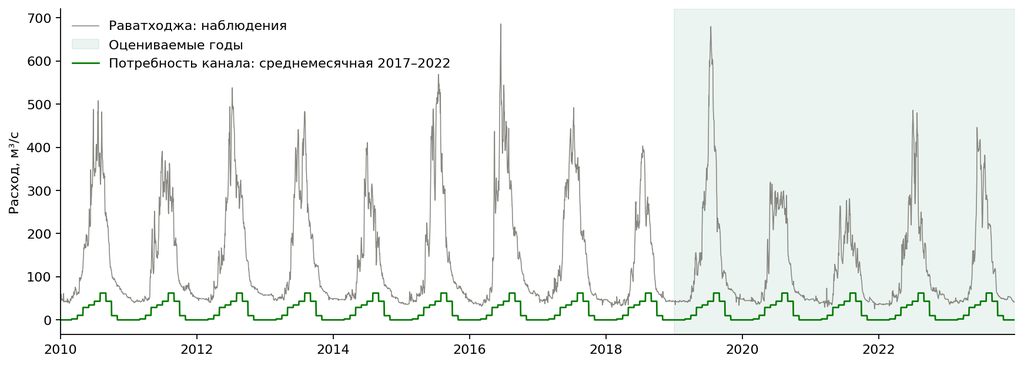

Рисунок 2: Естественный опорный ряд (серый, все 14 лет) и потребность канала (зелёный). Пять оцениваемых лет выделены фоном.

Два факта определяют всё дальнейшее. Потребность канала мала относительно реки: в среднем 19.6 м³/с при среднем расходе 135 м³/с; с ноября по февраль потребности нет. Но вода требуется в неудобное для реки время: отбор начинается в марте, когда ещё продолжается зимняя межень, достигает пика в августе и в сентябре всё ещё составляет 43 м³/с, хотя летнее половодье уже прошло.

# 3 Правило с двумя параметрами

`EFlowSplit` в TaqSim резервирует экологический сток до остальных распределений. У него два параметра:

- `eflow_fraction` — **резервируемая доля** суточного стока (от 0 до 1);
- `eflow_cap` — **верхний предел резерва**: резерв не превышает этот объём в сутки.

Суточный резерв равен *min(доля × сток, предел)*. Поэтому доля 100 % с пределом 60 м³/с означает: первые 60 м³/с каждого дня остаются в реке. Доля 50 % без предела означает: остаётся половина суточного стока. Затем правило `PriorityDistribution` у водозабора сначала снабжает поля в пределах месячной потребности, а остаток возвращает в реку.

```python
# Функция, соединяющая пять блоков для одного календарного года при одном плане. Прочитайте сверху вниз:
# суточная ось времени, приток как IntervalVolume, два конечных узла и два участка с правилами.
print(inspect.getsource(build_system))
```

```
def build_system(year: int, plan: Plan, inflow: pl.DataFrame | None = None) -> Any:
    """The five-block TaqSim system for one calendar year under one plan (built, not run)."""
    from taqsim import EFlowSplit, IntervalVolume, Parameter, PriorityDistribution, TimeAxis, WaterSystem, WaterVolume

    inflow = load_inflow() if inflow is None else inflow
    year_frame = inflow.filter(pl.col("date").dt.year() == year)
    series = pl.DataFrame(
        {"time": year_frame["date"].cast(pl.Datetime("us")), "value": (year_frame["q"] * DAY).round(0)}
    )
    system = WaterSystem(
        time=TimeAxis(datetime(year, 1, 1), year_frame.height, "1d"), quantum="1 m3", name="eflow-game"
    )
    system.source("inflow", IntervalVolume(series, "m3", "1d", "1 m3"))
    system.sink("fields")
    system.sink("river_end")
    system.reach(
        "headworks",
        "inflow",
        "canal_gate",
        rule=EFlowSplit(
            natural_ratios={"river_end": 1.0},
            remainder_ratios={"canal_gate": 1.0},
            eflow_fraction=Parameter("reserve_share", plan.share_pct / 100, (0.0, 1.0)),
            eflow_cap=WaterVolume(plan.cap_m3s * DAY, "m3"),
        ),
    )
    system.reach(
        "canal_gate",
        "headworks",
        "fields",
        rule=PriorityDistribution(
            "fields", tuple(WaterVolume(round(v * DAY), "m3") for v in demand_curve()), {"river_end": 1.0}
        ),
    )
    return system.build()
```

Несколько планов словами, как они называются в игре:

```python
for plan in (Plan(0, None), Plan(50, None), Plan(100, 60.0), Plan(50, 60.0), Plan(100, None)):
    print(f"доля {plan.share_pct:3d} %, предел {'нет' if plan.ceiling_m3s is None else f'{plan.ceiling_m3s:.0f} m³/s':10s} → {plan.name}")
```

```
share   0 %, ceiling none       → Canal takes all it needs
share  50 %, ceiling none       → Leave 50 % of each day's flow
share 100 %, ceiling 60 m³/s    → First 60 m³/s always stay
share  50 %, ceiling 60 m³/s    → Leave 50 %, at most 60 m³/s
share 100 %, ceiling none       → River untouched
```

# 4 Сборка и расчёт одного года

Рассчитаем самый маловодный из оцениваемых лет, 2021, с планом «первые 60 м³/с всегда остаются». Запуск занимает несколько секунд: новый расчётный механизм TaqSim записывает каждое распределение, позволяя воспроизвести и проверить расчёт.

```python
plan = Plan(100, 60.0)
run = run_year(2021, plan)  # YearRun: даты, естественный сток, река и поля в м³/с, время расчёта
demand = m.demand_daily(run.dates)
crops_2021 = 100 * run.fields.sum() / demand.sum()
Markdown(
    f"Run time {run.seconds:.1f} s for {len(run.dates)} daily steps. Mass balance residual {run.mass_balance_residual_m3():.0f} m³. "
    f"Поля получили {crops_2021:.1f} % потребности. Минимум ниже гидроузла {run.river.min():.1f} м³/с "
    f"(естественный {run.natural.min():.1f})."
)
```

Время расчёта 4.5 с для 365 суточных шагов. Невязка баланса 0 м³. Поля получили 89.8 % потребности. Минимальный расход ниже гидроузла 25.8 м³/с (естественный 25.8).

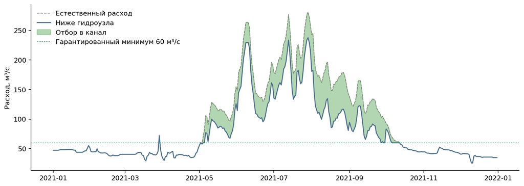

Рисунок 3: 2021 год при правиле «первые 60 м³/с всегда остаются». Зелёная полоса — вода, отобранная каналом.

Те же два правила умещаются в четырёх строках numpy. Модель хранит этот параллельный расчёт для проверки каждого запуска TaqSim: результаты совпадают с точностью до дискретности расчётного механизма — 1 м³ в сутки.

```python
print(inspect.getsource(twin_year))
river_twin, fields_twin = twin_year(run.natural, demand, plan)
print("наибольшая разница TaqSim − параллельный расчёт:", f"{np.abs(river_twin - run.river).max() * DAY:.2f} m³/day")
```

```
def twin_year(natural: np.ndarray, demand: np.ndarray, plan: Plan) -> tuple[np.ndarray, np.ndarray]:
    """The same two rules in numpy (river, fields in m³/s); checked against TaqSim in the tests."""
    reserve = np.minimum(plan.share_pct / 100 * natural, plan.cap_m3s)
    fields = np.minimum(demand, natural - reserve)
    return natural - fields, fields

largest difference TaqSim − twin: 0.40 m³/day
```

# 5 Оценка реки

Оценка реки — индекс IARI из fishy. Для него нужны 33 показателя IHA естественного ряда по отдельным годам и те же 33 показателя изменённого ряда за последние пять лет. Для каждого показателя проверяется, попало ли пятилетнее значение в естественный межквартильный диапазон (между 25-м и 75-м процентилями). Если да, оценка равна 0; если нет — расстоянию за границей диапазона, делённому на его ширину. Индекс — среднее по 33 показателям. Границы ISPRA: ≤ 0.05 — близко к естественному, ≤ 0.15 — хорошее состояние, выше — изменённое.

Перед числами важны две оговорки. Метод требует не менее 20 опорных лет; ряд Раватходжи содержит 14 (2010–2023). Руководитель проекта решил использовать доступные данные, поэтому модель изменяет проверку fishy (см. `model._fishy`). Если fishy не может оценить один из показателей, общий индекс не возвращается; тогда игра показывает среднее доступных показателей, их количество и причины пропусков.

```python
# Оценка двух планов за пять лет 2019–2023. run_grid рассчитывает годы параллельно (около десяти секунд).
# Два примера со страницы игры: доля и минимум, выбранные при экспорте
examples = [Plan(p["share_pct"], p["ceiling_m3s"]) for p in DATA["plans"] if p["id"] in META["teaching_pair"]]
runs = m.run_grid(examples, workers=5)
results = {p.id: m.evaluate_plan(p, runs[p.id]) for p in examples}
for r in results.values():
    s = r.river
    print(f"{r.plan.name:32s} культуры {r.crops_pct:5.1f} %  оценка {s.score:.3f} ({'все 33' if s.total is not None else f'{s.scored} из 33'} показателей)  класс {s.classification}")
    for w in r.warnings:
        print("   ⚠", w)
```

```
Leave 80 % of each day's flow    crops  81.9 %  score 0.167 (32 of 33 indicators)  class None
   ⚠ 1 of 33 indicators could not be scored (minimum_flow_date); the score is the mean of the other 32
   ⚠ minimum flow date: the date of the lowest flow cannot be scored: in the natural record it falls near the turn of the year, so the index cannot place the plan's dates on a circular axis
   ⚠ river below the lowest natural flow on record (25.8 m³/s) on 1 of 1826 days
First 80 m³/s always stay        crops  83.8 %  score 0.151 (all 33 indicators)  class non_buono
```

Почти одинаковый объём для культур, но разное состояние реки. Какие показатели создают эту разницу?

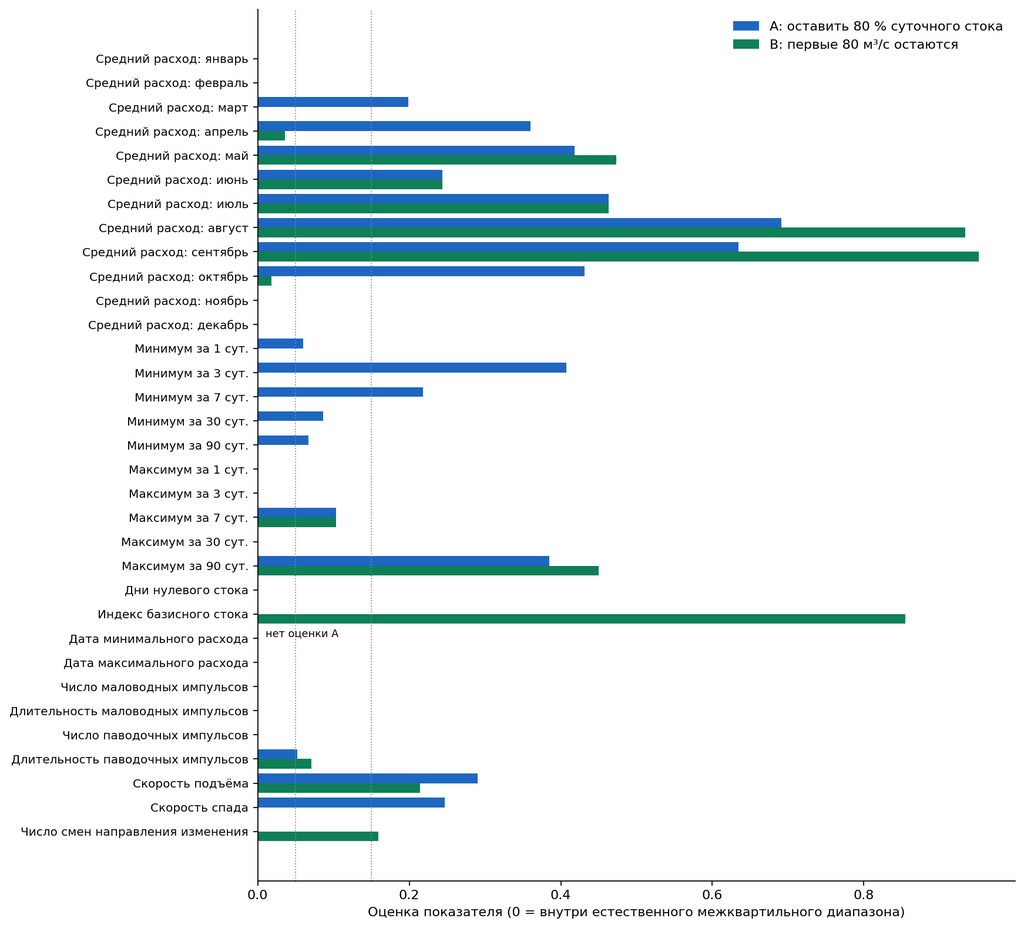

Рисунок 4: Оценки 33 показателей двух планов. Чем длиннее полоса, тем больше отклонение от естественного диапазона.

Правило доли отбирает больше всего воды в абсолютных величинах в дни высокого стока, что почти не влияет на индекс: эти дни остаются в естественном диапазоне. Но оно отбирает свою долю и в маловодные весенние дни, когда канал только начал работу: минимумы за 1, 3 и 7 дней и средние расходы весенних месяцев выходят за естественные границы. Гарантированный минимум в такие дни не допускает отбора. (Для плана A доступны лишь 32 из 33 показателей, поэтому его оценка — среднее по 32; ниже дано среднее плана B по тем же 32.)

```python
common = [k for k, v in a.river.indicators.items() if v is not None and b.river.indicators[k] is not None]
for r in (a, b):
    print(f"{r.plan.name:32s} среднее по {len(common)} общим доступным показателям: {np.mean([r.river.indicators[k] for k in common]):.3f}")
```

```
Leave 80 % of each day's flow    mean over the 32 indicators both can score: 0.167
First 80 m³/s always stay        mean over the 32 indicators both can score: 0.155
```

# 6 Все планы одновременно

Страница игры содержит сетку всех сочетаний параметров: доли 0–100 % с шагом 10, пределы 10, 20, 40, 60, 80, 100, 150 и 200 м³/с или отсутствие предела. При доле 0 % любой предел даёт один и тот же план, поэтому он представлен один раз: 91 план, каждый рассчитан в TaqSim за 2019–2023 и оценён через fishy. Загрузка готовых результатов вместо повторного расчёта сокращает работу блокнота.

```python
PLANS.filter(pl.col("unbeaten")).sort("crops_pct", descending=True)
```

shape: (43, 11)

| id str | name str | share_pct i64 | ceiling_m3s f64 | crops_pct f64 | score f64 | score_is_total bool | scored i64 | classification str | unbeaten bool | lowest_flow_m3s f64 |
| --- | --- | --- | --- | --- | --- | --- | --- | --- | --- | --- |
| "s0_cnone" | "Canal takes all it needs" | 0 | null | 100.0 | 0.30059 | false | 32 | null | true | 17.419 |
| "s10_c10" | "Leave 10 %, at most 10 m³/s" | 10 | 10.0 | 100.0 | 0.30059 | false | 32 | null | true | 17.419 |
| "s10_c20" | "Leave 10 %, at most 20 m³/s" | 10 | 20.0 | 100.0 | 0.30059 | false | 32 | null | true | 17.419 |
| "s10_c40" | "Leave 10 %, at most 40 m³/s" | 10 | 40.0 | 100.0 | 0.30059 | false | 32 | null | true | 17.419 |
| "s10_c60" | "Leave 10 %, at most 60 m³/s" | 10 | 60.0 | 100.0 | 0.30059 | false | 32 | null | true | 17.419 |
| … | … | … | … | … | … | … | … | … | … | … |
| "s100_c80" | "First 80 m³/s always stay" | 100 | 80.0 | 83.824 | 0.15067 | true | 33 | "non_buono" | true | 25.8 |
| "s100_c100" | "First 100 m³/s always stay" | 100 | 100.0 | 76.164 | 0.12702 | true | 33 | "buono" | true | 25.8 |
| "s100_c150" | "First 150 m³/s always stay" | 100 | 150.0 | 56.575 | 0.10131 | true | 33 | "buono" | true | 25.8 |
| "s100_c200" | "First 200 m³/s always stay" | 100 | 200.0 | 40.002 | 0.08277 | true | 33 | "buono" | true | 25.8 |
| "s100_cnone" | "River untouched" | 100 | null | 0.0 | 0.00444 | true | 33 | "elevato" | true | 25.8 |

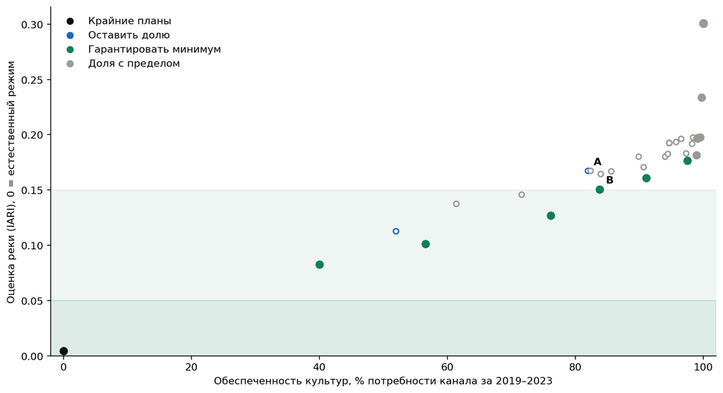

Рисунок 5: Все планы: обеспеченность культур и оценка реки. Закрашенные точки — планы, которые ни один другой не превосходит. Правее лучше для культур, ниже лучше для реки.

# 7 На что обратить внимание

2. **Небольшая доля почти ничего не меняет.** Среди планов только с долей 5 из 9 не меняют обеспеченность культур: канал редко требует больше остатка. Оценка не меняется до 40 %, состояние остаётся изменённым до 80 % и становится хорошим только при 90 %, когда культуры получают 52.0 %.

3. **Та же вода, другая река.** Пример A, «оставлять 80 % суточного стока», даёт культурам 81.9 % при оценке 0.167; пример B, «первые 80 м³/с всегда остаются», даёт 83.8 % при 0.151. Минимум защищает маловодные дни, доля — нет.

4. **Недоминируемые планы.** Для 43 из 91 плана нет другого плана, превосходящего его; 7 из них задают гарантированный минимум. Выбор между ними — решение о компромиссе между рекой и культурами, а не результат вычисления.

# 8 Ограничения

- **Один канал.** Реальный гидроузел Раватходжи также питает переброски в Джизак и Кашкадарью и другие каналы; здесь воду забирают только три Самаркандских канала. Поэтому реальная доля отбора больше, а компромисс острее.
- **Нет накопления, потерь и возвратного стока.** В канале нет фильтрации, с полей нет возврата, вода не переносится между днями. Игра изучает правило гидроузла, а не весь бассейн.
- **Фиксированная кривая потребности.** Канал каждый год запрашивает одинаковые месячные объёмы; маловодный год не меняет потребности культур.
- **Одно правило на все дни.** Реальные правила экологического стока меняются по сезонам и типам года; в исследованиях их разрабатывают сразу для многих целей (Suen & Eheart 2006; Chen & Olden 2017). Здесь оба параметра неизменны весь год.
- **Опора на современный режим.** Сток Зарафшана у Раватходжи регулируется выше по течению; 2010–2023 — современный ряд, а не нетронутая река. В нём 14 лет вместо требуемых 20, поэтому естественные квартили менее определённы, чем предполагает метод; пять оцениваемых лет входят и в опорный период.
- **Один индекс.** IARI измеряет изменение гидрологического режима, но ничего не говорит о рыбе, температуре и наносах.

# 9 Упражнения

1. Рассчитайте `Plan(100, 40.0)` за 2021 год через `run_year` и проверьте минимальный расход ниже гидроузла. Почему он не равен 40 м³/с? (См. естественный минимум в разделе 2.1.)
2. Добавьте третье семейство правил: долю, действующую только с марта по май. Само правило `EFlowSplit` этого не делает; предложите дополнительный блок и его правило.
3. Замените кривую потребности суммой шести каналов из файла потребностей (`m.SAMARKAND_CANALS` и три других столбца), пересчитайте два примера. Как меняется компромисс?
4. В таблице оценок найдите план с лучшей оценкой реки среди планов, обеспечивающих культуры более чем на 95 %. Это доля, минимум или доля с пределом?

# 10 Источники

- Suen, J.-P. & Eheart, J. W. (2006). Reservoir management to balance ecosystem and human needs: incorporating the paradigm of the ecological flow regime. *Water Resources Research* 42, W03417.
- Chen, W. & Olden, J. D. (2017). Designing flows to resolve human and environmental water needs in a dam-regulated river. *Nature Communications* 8, 2158.
- Richter, B. D., Baumgartner, J. V., Powell, J. & Braun, D. P. (1996). A method for assessing hydrologic alteration within ecosystems. *Conservation Biology* 10, 1163–1174.
- ISPRA (2011). Implementazione della Direttiva 2000/60/CE: analisi e valutazione degli aspetti idromorfologici. Manuali e Linee Guida 131/2011. Индекс IARI и границы классов в реализации fishy.
- hydrosolutions. *fishy*: диагностика экологического стока для TaqSim. github.com/hydrosolutions/fishy, коммит 881660e.
- hydrosolutions. *TaqSim*. github.com/hydrosolutions/taqsim, коммит 396ad09.
- Данные: `data/ZRB_baseline/inflow/inflow_ravatkhoza_daily_2010_2023.csv` (суточный сток Раватходжи) и `data/ZRB_baseline/demand/demand_all_districts_2017-2022_monthly.csv` (месячные потребности каналов), оба файла в репозитории Zarafshan TaqSim.